# Testando homocedasticidade em dados multivariados

Muitos testes de hipótese multivariados (ver este roteiro) baseiam-se na homocedasticidade das matrizes de covariância, que é o análogo multivariado da homogeneidade de variâncias em testes de hipótese univariados (por exemplo, usando o teste de [Levene](https://en.wikipedia.org/wiki/Levene%27s_test) para avaliar homocedasticidade univariada).

Neste roteiro vamos abordar dois tipos de testes para avaliar se as matrizes de covariância são homogêneas em testes de hipótese comparando médias em diferentes grupos.

# Dados

Como exemplo, vamos utilizar os dados de medidas morfológicas de pardais que sobreviveram e que não sobreviveram à uma tempestado disponibilizados no material que acompanha o livro de Manly and Navarro Alberto (2017) (baixe os dados [aqui](https://www.researchgate.net/publication/311283141_R_code_and_data_sets)).

```r
pardais <- read.csv("Bumpus sparrows.csv",header=TRUE)
```

```r
cov(pardais[pardais$Survivorship == "S", -1])
```

```
##                Total_length Alar_extent L_beak.head L_humerous L_keel_sternum
## Total_length      11.047619        9.10   1.5566667     0.8700      1.2861905
## Alar_extent        9.100000       17.50   1.9100000     1.3100      0.8800000
## L_beak.head        1.556667        1.91   0.5313333     0.1890      0.2396667
## L_humerous         0.870000        1.31   0.1890000     0.1760      0.1325000
## L_keel_sternum     1.286190        0.88   0.2396667     0.1325      0.5749048
```

```r
cor(pardais[pardais$Survivorship == "NS", -1])
```

```
##                Total_length Alar_extent L_beak.head L_humerous L_keel_sternum
## Total_length      1.0000000   0.7761963   0.6769768  0.6824212      0.6568714
## Alar_extent       0.7761963   1.0000000   0.6978185  0.7845546      0.6200093
## L_beak.head       0.6769768   0.6978185   1.0000000  0.8347046      0.5698878
## L_humerous        0.6824212   0.7845546   0.8347046  1.0000000      0.6677936
## L_keel_sternum    0.6568714   0.6200093   0.5698878  0.6677936      1.0000000
```

Para facilitar a inspeção visual, eu fiz a diferença entre as correlações do grupo não-sobrevivente com o sobrevivente.

```r
cor(pardais[pardais$Survivorship == "NS", -1]) - cor(pardais[pardais$Survivorship == "S", -1])
```

```
##                Total_length Alar_extent L_beak.head L_humerous L_keel_sternum
## Total_length     0.00000000  0.12172887  0.03446994 0.05850172      0.1465157
## Alar_extent      0.12172887  0.00000000  0.07144870 0.03811285      0.3425714
## L_beak.head      0.03446994  0.07144870  0.00000000 0.21665701      0.1362510
## L_humerous       0.05850172  0.03811285  0.21665701 0.00000000      0.2512489
## L_keel_sternum   0.14651569  0.34257144  0.13625102 0.25124892      0.0000000
```

Aqui, podemos ver que, apesar de muitas correlações terem uma diferença pequena, todas as diferenças são positivas indicando que o grupo não-sobrevivente possui maior variabilidade nas medidas morfológicas do que o grupo sobrevivente. Seriam estas diferenças significativas?

# Teste M de Box (Box M-test)

Este teste compara a variação em duas ou mais amostras multivariadas. É considerado um testes sensível à premissa de normalidade multivariada, e portanto é possivel que um resultado significativo seja devido à não normalidade dos dados do que à matrizes de covariância não homogêneas (Manly and Navarro Alberto (2017)).

Vamos primeiro observar a normalidade multivariada dos dados (roteiro útil aqui).

```
##    Mardia's Multivariate Normality Test
## ---------------------------------------
##    data : pardais[, -1]
##
##    g1p            : 5.139891
##    chi.skew       : 41.97578
##    p.value.skew   : 0.1941829
##
##    g2p            : 35.93328
##    z.kurtosis     : 0.3904202
##    p.value.kurt   : 0.6962258
##
##    chi.small.skew : 45.45482
##    p.value.small  : 0.1110146
##
##    Result         : Data are multivariate normal.
## ---------------------------------------
```

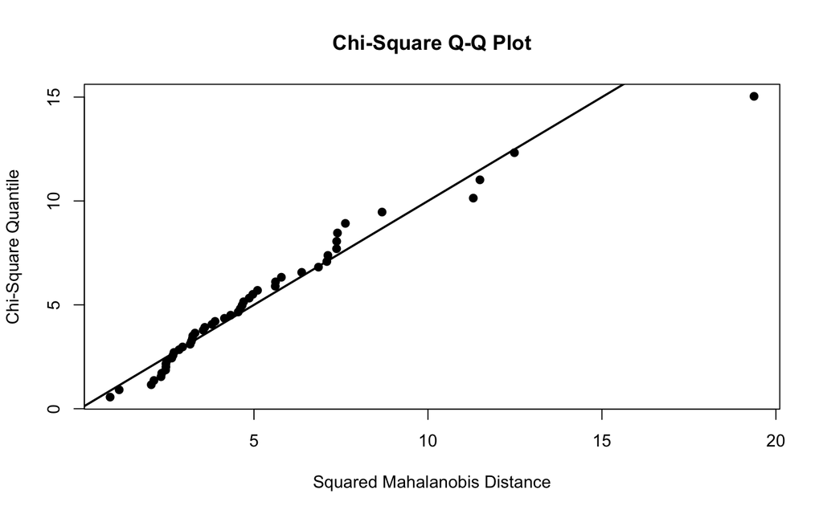

```r
library(MVN)
mardiaTest(pardais[,-1], qqplot=T)
```

Agora vamos apliar o teste M de box que está disponível no pacote `biotools` com a função `boxM`. Nesta função, damos a matriz de variáveis quantitativas que queremos comparar e o vetor que identifica os grupos a serem comparados.

```r
library(biotools)
boxM(pardais[,-1], pardais[,1])
```

```
##
##  Box's M-test for Homogeneity of Covariance Matrices
##
## data:  pardais[, -1]
## Chi-Sq (approx.) = 10.408, df = 15, p-value = 0.7933
```

Com este teste, concluimos que as diferenças que observamos nas matrizes de correlação não são signficativas. Então, podemos dizer que há homocedasticidade multivariada nos dados.

# Método PERMDIST: uma generalização do teste de Levene univariado

A função `betadisper()` do pacote `vegan` faz o teste e o `help(betadisper)` provém bastante informação interessante sobre essa abordagem, vale a pena conferir!

```r
library(vegan)
pardist <- dist(pardais[,-1], "euclidian")
mod <- betadisper(pardist, pardais[,1])
anova(mod)
```

```
## Analysis of Variance Table
##
## Response: Distances
##           Df Sum Sq Mean Sq F value Pr(>F)
## Groups     1   19.6 19.6021  2.3021 0.1359
## Residuals 47  400.2  8.5149
```

O resultado deste método também indica homocedasticidade entre as matrizes de covariância para os pardais sobreviventes e não sobreviventes.

O legal desta abordagem é que conseguimos desenhar um gráfico dos eixos de uma Análise de Coordenadas Principais ( PCoA), comparando os grupos.

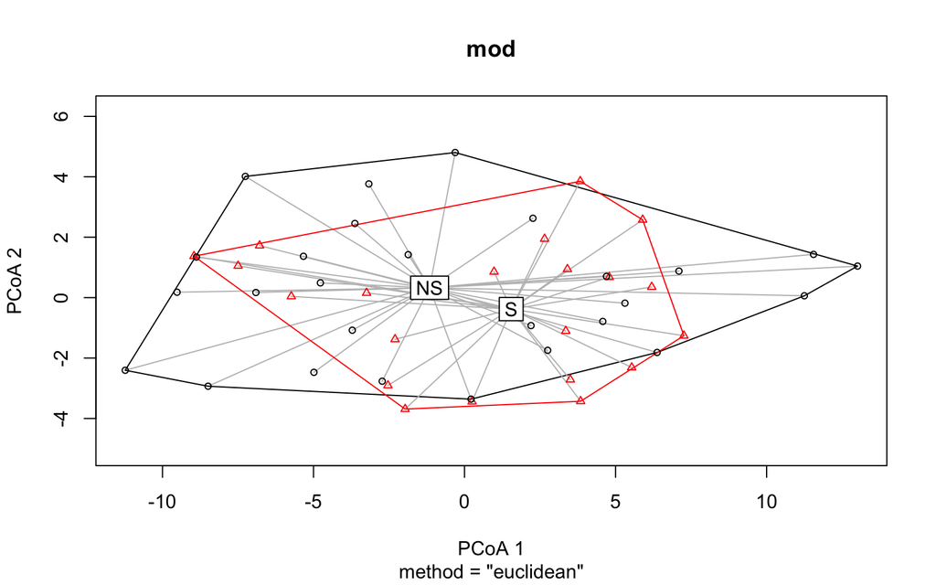

```r
plot(mod)
```

# Referências

Anderson, M.J. (2006) Distance-based tests for homogeneity of multivariate dispersions. Biometrics 62, 245–253.

Manly, Bryan F. J., and Jorge A. Navarro Alberto. 2017. *Multivariate Statistical Methods: A Primer*. Fourth edition. Boca Raton: CRC Press.

Melina de Souza Leite

05 de Fevereiro de 2018